# GDP analysis and trends

Kaidi Chen, Ziliang Huang, Weixiao Sun

2/16/2022

**Code name** : GDP

**Project title** : GDP analysis and trends

**Authors** :

- Ziliang Huang: zlhuang@uw.edu
- Kaidi Chen: kaidic@uw.edu
- Weixiao Sun: wsun9@uw.edu.

**Affiliation** : INFO-201: Technical Foundations of Informatics - The Information School - University of Washington

**Date** : Winter 2022

**Keywords** : *Economic, Development, Society, Macroscopic*

## Abstract :

Our analysis mainly focus on the impact of **Inflaction, Unemployment, and Population** to GDP in United States. GDP is one of the key indicators of the overall economic strength of a country, or even the global economy. Therefore, since we have majors in financial-related fields, we are very interested in this topic and eager to discover what factors affect GDP and how much they can interact.

## Introduction :

Our study project will be focused on the issue of globalized Gross Domestic Product, which is a key indication of national economic data and a common gauge of a region’s economic status and overall degree of development. In general, the GDP of a country may be split into three categories: value, income, and product. It is the difference in value between the total value of all products and services generated by all resident units in a given period and the total value of all non-fixed assets, goods, and services invested in the same period. More specifically, we will investigate the influence and link between population, inflation, and unemployment on GDP. Meanwhile, using data from 2000 to 2021, we will analysis the economic environment across all region and for forecast for the future.

## Design Situation:

GDP is no longer debatable since it provides information about the size of an economy and how well it is operating. Furthermore, as experts in International Monetary Fund put it, the GDP growth rate is frequently employed as an indication of the overall health of the economy. Furthermore, if the GDP of a certain nation or area rises, it will be an essential indicator for that country or region that the economy is doing well, which will allow governments to plan ahead of time particular measures.

“GDP is a lousy measure of economic welfare,” argues Alan Krupnick, an economist at Resources for the Future.”Economists prefer to look at aggregate economic measures such as unemployment rates and GDP rather than going into distributional concerns such as who is affected, who is losing money, where is this GDP growth truly coming from, and does it enhance societal equity?” Thus, in our study, we will primarily focus on doing research to determine where GDP growth is coming from and analyzing how such economic indicators that economists mostly focus on connect to GDP.

The advantages of our idea are evident; it may assist countries in developing and formulating stronger economic strategies. The disadvantage of our research is that the GDP effect elements we investigate are quite restricted, which may mislead those who are worried about our project into focusing solely on inflation, unemployment, and population as the key issues. In reality, there may be an increasing number of essential aspects.

## Research questions:

- **How the population, the unemployment rate, and the inflation and end of period consumer prices affect the GDP in the USA?**

  We will perform data visualization to draw three distributions and find the correlation coefficient to judge the relationship between population and GDP.
- **What are the comparative GDP trends for these three countries (China, Germany, United States) from 2000 to 2021?**

  We use data visualization to draw a world map to see the average GDP distribution of various countries from 2000 to 2021.

## The Dataset

The origin of our data is from the [International Monetary Fund (IMF)](https://www.imf.org/en/Publications/WEO/weo-database/2021/October), an organization working to foster global monetary cooperation, secure financial stability, facilitate international trade, promote high employment and sustainable economic growth and reduce poverty around the world. The data set we are going to use for this project is 8823 rows and 57 rows, and covers all economic data (e.g. Unemployment, Inflation, GDP, Population) for 190 countries in the world from 1980 to 2021. However, we will only use certain structure of data from the whole set, the population,unemployment, inflation and GDP of all regions from 2000 to 2021 to complete our research question. We only extract these data and compare to United States since the US has changed dramatically in the last 20 years. I think the difficulty with this dataset is whether we can extract the right economic data we need correctly and efficiently. However, there are certain data that are missing in this dataset, which input as “n/a”. Moreover, these data are printed into different types of units, including index, number of people, US dollars, and national currency. Hence, we may end up with different numbers of X and Y arguments when we plot them into our graph. Additionally, the class of all the values in this dataset is actually characters, which will let us make mistakes when calculating and graphing this dataset. Thus, we have to convert all the data that we need to calculate into numerical class. As we mentioned above, since we only need two types of data, population, and GDP, which are presented horizontally, their classification is written in a “subject descriptor” column and even the GDP data has several different classifications for each country. Besides, the values in the “subject descriptor” column are complex and are difficult for us to extract corresponding columns for our analysis. This may lead to additional difficulties in the process of data extraction, depending on whether we can find consistent patterns in them. What’s more, we discover that the “Country” and the “Region” columns are not factors, thus making our analysis difficult to proceed. In addition, there are too many features in this database and many of them are not related to our project’s topic, so we have to reorganize this dataset to make it cleaner.

## Expected Implications

For data visualization, technologists must utilize R. Simultaneously, in terms of the link between GDP and its connected elements, we expect to compute the correlation coefficient, r value, and p value to see whether there is a linear relationship that will assist us in forecasting. Designers are required to utilize R markdown to create a dynamic report that better displays our analyzing results, allowing our analysis to be understood by persons other than those in such a professional sector. Policymakers are obligated to safeguard our data analysis findings and guarantee the transparency of our data resources.

## Limitations

Our research will be largely focused on the impacts of population, inflation, and unemployment on GDP, and because GDP is impacted by multiple factors and data restrictions, the research project’s conclusions may not acquire the predicted trends. The unemployment rate and GDP growth seem to have a reasonably consistent connection. In any event, this link is not particularly rigid and should be evaluated based on the circumstances of the country or region.

## Summary information

Our project research focuses on observing and analyzing global GDP statistics by analyzing a variety of corresponding impacts. We have selected six distinct variables from our data that we consider are relevant. Specifically, the number of observations, variables, the maximum value of GDP in 2021 (billion), the minimum value of GDP in 2021 (billion), the maximum value of population in 2021 (million), and the minimum value of population in 2021 (million). The change in the trend of global GDP is seen by looking at the production in conjunction with the effect of numerous independent variables.According to the data, the number of observations for the total data is 7636 . The number of variavbles for the total data is 26 . The maximum value of GDP in 2021 is 22939.58 billion, and the minimum value is 0.065 billion; the maximum value of population in 2021 is 1418.11 million, and the minimum value of population in 2021 is 0.011 million. The population maximum in 2021 and the population minimum in 2021. We may infer the amount and trend of the independent variable’s influence on the dependent variable from the data, enabling us to compute the difference caused by that demographic component on GDP. By analyzing this data, we can identify the amount to which various factors influence GDP and, as a result, better formulate efficient strategies for the development of the country’s GDP in order to achieve economic development.

We have used `nrow(data)` to find out the number of observations, which is `summary_info$num_observations`, and for the the number of variables `summary_info$num_variables` we used `ncol(data)`to obtain the output. The maximum value of GDP (in billion) in 2021 is stored in the variable `summary_info$max_GDP_2021` . For the minimum value of GDP(in billion) in 2021, the variable name is `summary_info$min_GDP_2021`. Then for the the maximum value of population in 2021 (million), we have the independent variable `summary_info$max_population_2021`, and we receive the the minimum value of population in 2021 (million) by the variable `summary_info$min_population_2021`.

## Table

For the aggregated table below, it calculates the average GDP in each Country from 2000 to 2021. The table displays only the Top 10 country with the highest GDP in *Billions* of the past twenty years across all regions.

| Country | Average GDP |
| --- | --- |
| United States | 15883 |
| China | 7391 |
| Japan | 5019 |
| Germany | 3294 |
| United Kingdom | 2581 |
| France | 2427 |
| Italy | 1918 |
| India | 1633 |
| Brazil | 1567 |
| Canada | 1446 |

## Chart1

**Purpose:** Scatter plot — uses to observe and show the relationships between two numeric variables.

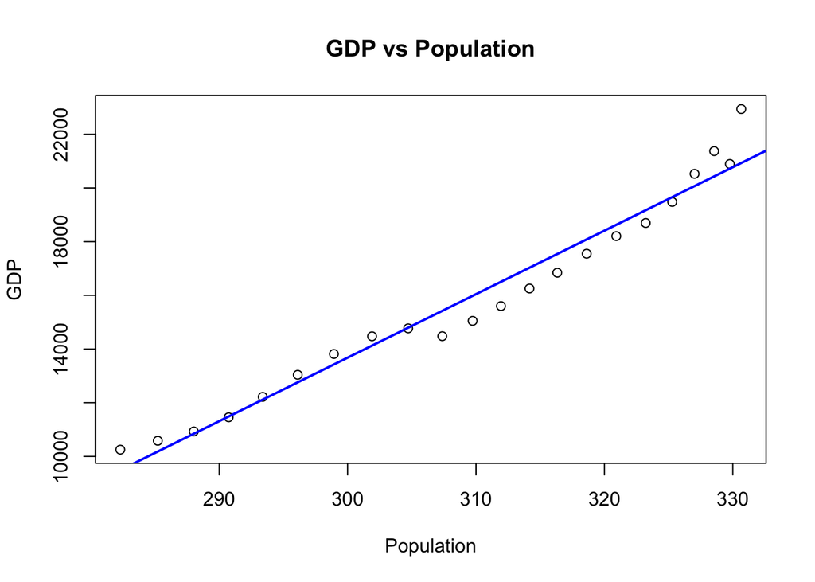

```
##
##  Pearson's product-moment correlation
##
## data:  x and y
## t = 23, df = 20, p-value = 0.0000000000000007
## alternative hypothesis: true correlation is not equal to 0
## 95 percent confidence interval:
##  0.9554 0.9925
## sample estimates:
##    cor
## 0.9816
```

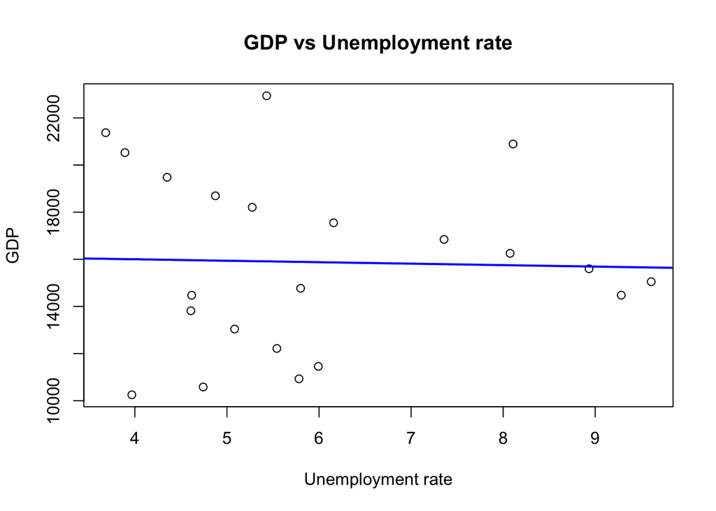

```
##
##  Pearson's product-moment correlation
##
## data:  x and y
## t = -0.14, df = 20, p-value = 0.9
## alternative hypothesis: true correlation is not equal to 0
## 95 percent confidence interval:
##  -0.4463  0.3963
## sample estimates:
##      cor
## -0.03038
```

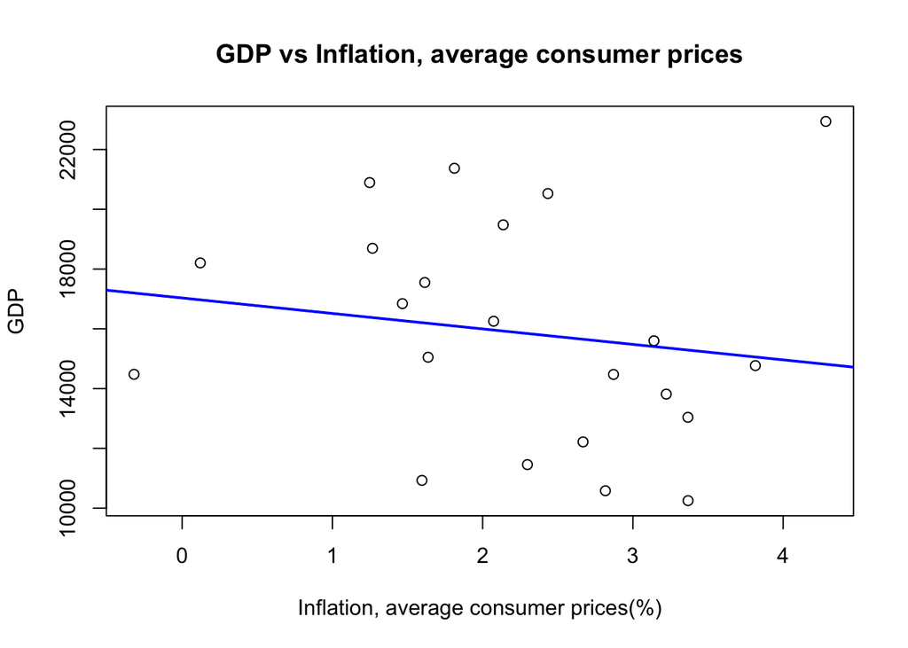

```
##
##  Pearson's product-moment correlation
##
## data:  x and y
## t = -0.71, df = 20, p-value = 0.5
## alternative hypothesis: true correlation is not equal to 0
## 95 percent confidence interval:
##  -0.5429  0.2831
## sample estimates:
##     cor
## -0.1573
```

## Chart2

#### What are the comparative GDP trends of China, Germany, United States since year of 2000?

**Purpose:** Line Graph — uses lines to connect individual data points and displays quantitative values over a specified time interval.

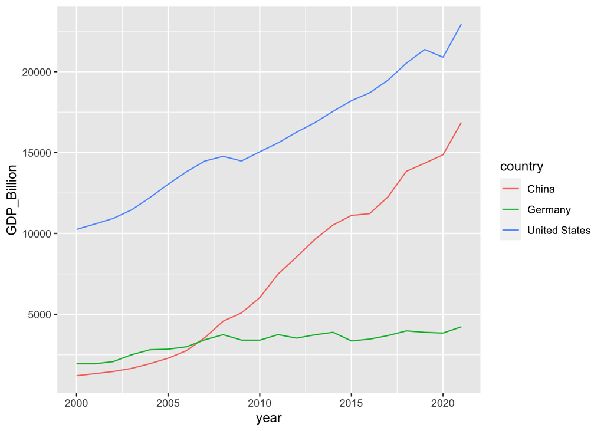

## Chart3

#### Research Question: How does the average GDP compare across different countries around the world?

A choropleth map was created to show a comparison of the average GDP values for each country from 2000 to 2021. The different average GDP values are indicated by the shades of color. It is more intuitive to apply the map to analyze and present the average GDP data for each country around the world in relation to its geographical location.

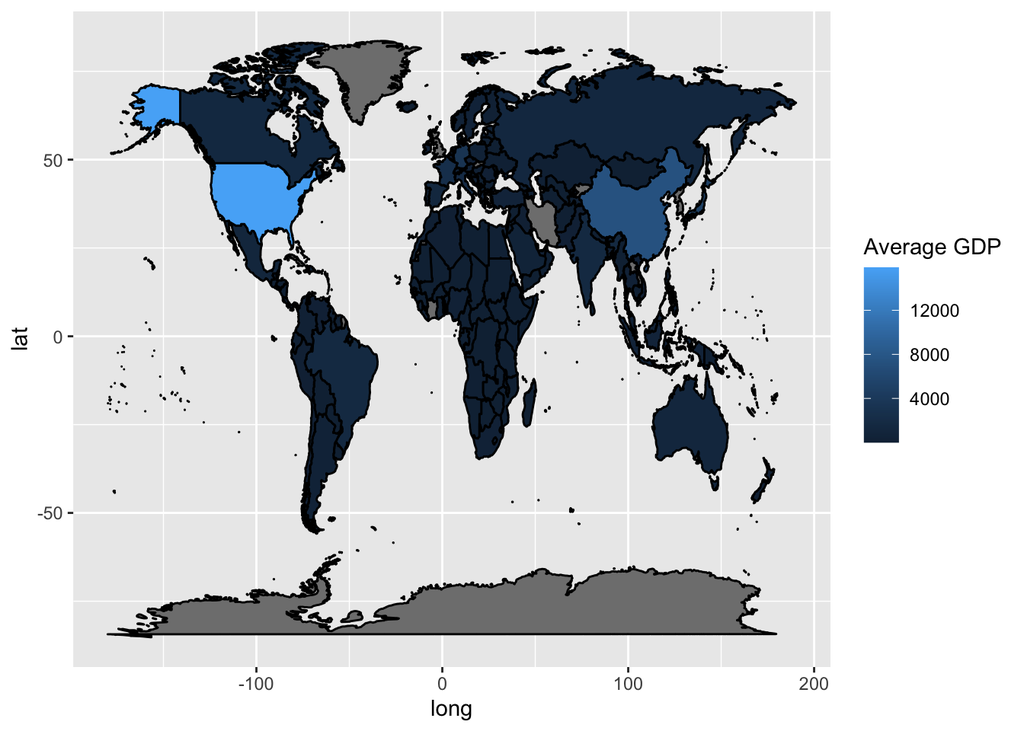

## Acknowledgements:

We would like to say thank you to my TA, the instructor and everyone on my team. Beside, we appreciate that International Monetary Fund collected the World Economic Outlook Database for our project.

## References:

- Tim Callen, International Monetary Fund(2020).Gross Domestic Product: An Economy’s All. https://www.imf.org/external/pubs/ft/fandd/basics/gdp.htm#:~:text=GDP%20is%20important%20because%20it,the%20economy%20is%20doing%20well.
- Adam Rogers, the WIRED (2020). How Much Is a Human Life Actually Worth? https://www.wired.com/story/how-much-is-human-life-worth-in-dollars/
- BBC News(2021). What is GDP and how is it measured? https://www.bbc.com/news/business-13200758
- International Monetary Fund(2021). World Economic Outlook Database. https://www.imf.org/en/Publications/WEO/weo-database/2021/October/download-entire-database